# Know Texas Electricity Prices

Monday, June 23, 2014

## Electricity Market

In Texas, although most of our electricity bills show a flat rate, the electricity retailers buy electricity from whole sale market at different prices. The prices normally vary with day, time and location.

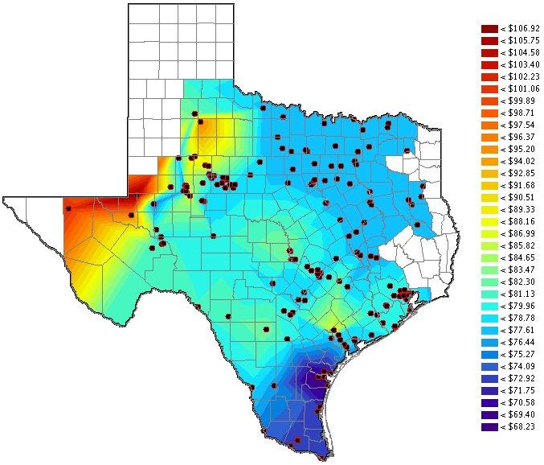

The Shiny application demonstrates the differences of electricity prices between days of week and hours of day.

## Prepare the data

The electricity price data are downloaded from http://www.ercot.com.

The prices are located at Market Information -> Market Prices -> DAM Settlement Point Prices.

- Downloads the last thirty days data in csv format.
- Read unzipped csf files into R.
- Subset the data by keeping data with settlement point name of HB_HUBAVG.
- Calculate the median prices group by day of the week and hour of the day.

Notes: HB_HUBAVG is ERCOT Hub Average 345kv Hub price which is considered as an ERCOT-wide price.

## ui.R : user picks the day

User can view the 24 hours' electricity prices by choosing the day of week (Sunday, Monday, Tuesday, etc.), then the curve will be updated.

```
shinyUI(fluidPage(
  sidebarLayout(
    sidebarPanel(
        selectInput("wDay", "Choose a day:",
          choices = c('Sunday','Monday','Tuesday'
            ,'Wednesday','Thursday','Friday','Saturday'))
    ),
    mainPanel(
      plotOutput("curvePlot")
    )
  )
))
```

## server.R : gets the day then plot curve

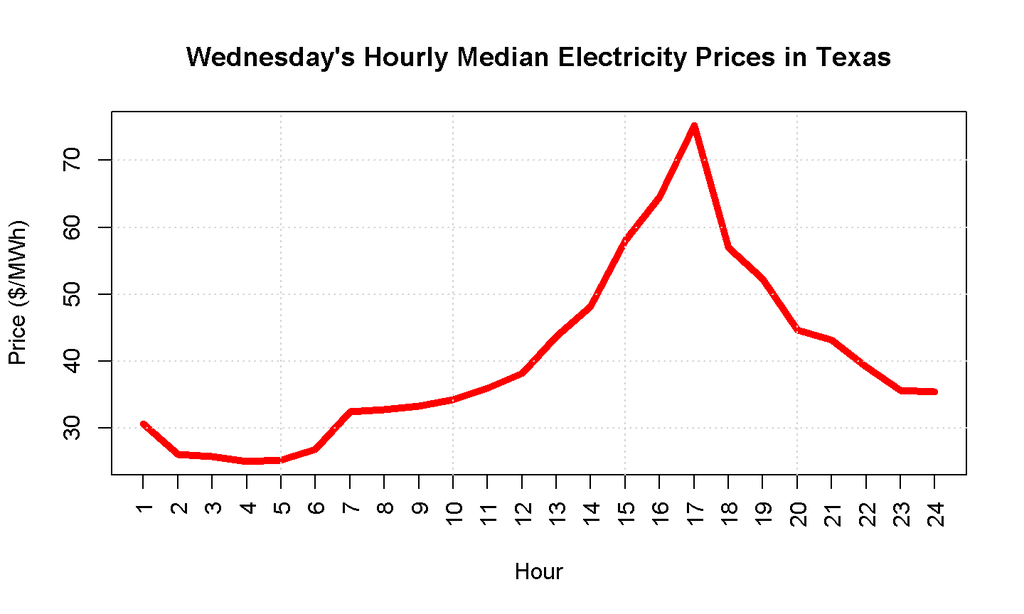

```r
plot(data$Hour, data$Price, type = "l", main = title, xlab = "Hour",
     ylab = "Price ($/MWh)", col = "red", lwd = 5, xaxt="n")
axis(1, at = seq(1, 24, by = 1), las=2)
grid()
```